# Late-Night Gaming, Sleep and Wellbeing

The Pri(n)ce of Playing Past Bedtime

Authors

Affiliations

[Tamás A. Földes](https://example.com)

Published

December 9, 2025

Abstract

# Introduction

Concerns have been raised about the potential negative impacts of video gaming on sleep and overall wellbeing, particularly for adolescents and young adults and especially when gaming occurs late at night (Altintas et al. 2019; Exelmans and Van Den Bulck 2015; Higuchi et al. 2005; King et al. 2013; Peracchia and Curcio 2018). Late-night gaming has been shown to disrupt sleep patterns, reduce sleep duration, lower sleep quality, and increase daytime sleepiness (Exelmans and Van Den Bulck 2015; Han, Zhou, and Liu 2024; Kristensen et al. 2021). This is especially concerning given the far-reaching effects of sleep disturbances on cognitive and emotional functioning (Cain and Gradisar 2010; LeBourgeois et al. 2017; McCoy and Strecker 2011; Simon et al. 2020; Vriend et al. 2013). For instance, habitual gaming between 10 p.m. and 6 a.m. has been associated with an increased risk of depressive symptoms, partially mediated by daytime sleepiness (Lemola et al. 2011). Understanding the consequences of late-night gaming is thus vital for both gamers and health professionals.

## Mechanisms Linking Late-Night Gaming to Sleep Disturbance

Two key mechanisms have been proposed to explain the impact of late-night digital engagement—including gaming—on sleep. The first is the **displacement hypothesis**, which argues that late-night gaming is more harmful than daytime gaming because it cuts into sleep time (Twenge 2019; Williams, Yee, and Caplan 2008). Gamers often feel compelled to continue playing and struggle with self-regulation, which can lead to insufficient sleep (King and Delfabbro 2009; Pirrone, Eijnden, and Peeters 2024; Spada and Caselli 2017). For example, adolescents experiencing a heightened sense of “flow” during challenging games delayed bedtime by up to 90 minutes (Smith et al. 2017).

The second mechanism involves **arousal-related disturbances** in sleep architecture caused by late-night gaming. Empirical studies have shown that extended gaming, especially when involving violent content, significantly decreases REM sleep and total sleep time (King et al. 2013). Weaver et al. (2010) highlighted that increased arousal levels due to pre-sleep gaming extend sleep latency and alter the natural progression into sleep stages. This delay in sleep onset could be exacerbated by lower melatonin levels following an evening of gaming, compared to neutral activities like board games, which are crucial for regulating the sleep-wake cycle (Hartmann et al. 2019).

## The Moderating Role of Chronotype

Negative effects of late-night gaming are often compounded among individuals with an eveningness chronotype—a group naturally predisposed to staying up late. Problematic gamers, who frequently possess this chronotype, are especially vulnerable to the detrimental effects of late-night gaming on sleep (Kristensen et al. 2021). Pre-sleep technology use may exacerbate the misalignment between their biological clock and societal demands by delaying sleep onset and reducing sleep duration, leading to poorer sleep quality and increased daytime sleepiness.

Research has linked evening chronotype in adolescents to greater technology use at bedtime, in turn associated with delayed sleep onset, shorter sleep duration, and poorer sleep quality (Bruni et al. 2015; Gumport et al. 2021; Kortesoja et al. 2023; Reardon, Lushington, and Agostini 2023). Additionally, while Reardon, Lushington, and Agostini (2023) found that shorter sleep on weekdays was associated with greater psychological distress, technology medium and chronotype were not direct predictors of distress. Gumport et al. (2021) found that technology use improved emotional, social, cognitive, and physical health but worsened behavioral health, measured by the consumption of junk food, caffeine, alcohol, tobacco, and other substances, in evening-type adolescents. It remains unclear how strongly these findings apply to young adults and adults, as most research has focused on adolescent populations. This leaves an open question about the extent to which evening chronotypes in older age groups are similarly affected by pre-sleep technology use.

## The Present Study

In sum, the literature indicates that video gaming, particularly when it occurs late at night, has significant implications for sleep quality, sleep duration, and overall wellbeing. This disruption can be attributed to both the displacement hypothesis (Twenge 2019; Williams, Yee, and Caplan 2008) and arousal-related disturbances in sleep architecture (King et al. 2013). Individual differences, such as chronotype, may moderate these effects, with eveningness chronotypes particularly vulnerable to the negative consequences of late-night gaming (Kristensen et al. 2021). The present study aims to empirically test the following hypotheses regarding the relationship between late-night gaming and sleep outcomes:

In addition to testing direct relationships between late-night gaming and various sleep-related outcomes are critical to understand, we further assess the potential moderating role of chronotype, which refers to a person’s natural preference for activities during certain times of the day—morningness or eveningness. Individuals with an evening chronotype tend to stay up later and may be more inclined to engage in late-night gaming, potentially exacerbating the negative impacts on sleep and wellbeing. The combination of an evening chronotype and late-night gaming may even have a compounded effect on overall wellbeing, as both factors are independently associated with poorer mental health outcomes. Given this, we propose the following:

**H2**: Chronotype moderates the relationships between late-night gaming and all outcomes in H1 (sleep quality, sleep duration, daytime sleepiness, and wellbeing), such that these negative associations are stronger for individuals with more of an eveningness chronotype.

By examining chronotype on a continuous scale as a moderating factor, this study seeks to provide a more nuanced understanding of the potential risks associated with late-night gaming and to identify individuals who may be most vulnerable to its negative effects.

# Methods

## Data Source and Measures

The analyses reported here are part of a Stage 1 Registered Report (Ballou et al. 2024) and utilize data from the Open Play dataset (Ballou et al. 2025), a longitudinal study that collected multi-platform video game digital trace data alongside psychological measures from adult gamers in the UK and US over a three-month period. The study combined objective behavioral telemetry from gaming platforms with repeated self-report surveys administered biweekly across six waves. Importantly, the present analyses use only a subset of the Open Play dataset, specifically data from Nintendo, Xbox, and Steam platforms, as these provide session-level (Nintendo, Xbox) or near session-level (Steam) temporal granularity necessary for hourly aggregation of playtime to operationalize late-night gaming (23:00–06:00). The following validated measures were administered via panel surveys at multiple timepoints: Wellbeing was assessed using the Short Warwick-Edinburgh Mental Well-being Scale [SWEMWBS; Tennant et al. (2007)], a 7-item measure of mental wellbeing covering psychological functioning and subjective well-being over the past 2 weeks, with responses on a 5-point Likert scale ranging from “None of the time” to “All of the time” (score range: 7–35). Sleep quality and duration were assessed using the Pittsburgh Sleep Quality Index [PSQI; Buysse et al. (1989)], a 19-item questionnaire evaluating sleep quality over the past month. The measure yields seven component scores (sleep quality, sleep latency, sleep duration, sleep efficiency, sleep disturbances, use of sleep medication, and daytime dysfunction) and a global score (range: 0–21), with scores above 5 indicating poor sleep quality. Excessive daytime sleepiness was measured using the Epworth Sleepiness Scale [ESS; Johns (1991)], an 8-item scale assessing the likelihood of dozing off in various situations (score range: 0–24). Higher scores indicate greater propensity for daytime sleepiness, with scores above 10 typically indicating clinically significant excessive sleepiness. Chronotype was measured at baseline (Wave 1) using the Munich Chronotype Questionnaire [MCTQ; Roenneberg, Wirz-Justice, and Merrow (2003)]. The key metric used in this study is MSF<sub>sc</sub> (Mid-Sleep on Free Days corrected for sleep debt on work days), which represents an individual’s natural sleep-wake preference when not constrained by social obligations. Higher MSF<sub>sc</sub> values indicate a preference for eveningness (later sleep-wake times).

## Handling Missing Data

The imputed outcomes serve as the primary analytic dataset throughout the main text. Complete-case versions of every regression (using only non-imputed observations for each outcome) were re-estimated in parallel and included in the Supplement.

# Results

## Data Quality Controls

Prior to hypothesis testing, we conducted three positive data quality controls (DQCs) to validate expected patterns in the data. First, self-reported playtime was significantly correlated with digital trace playtime (r = 0.49, 95% CI [0.47, 0.51], p < .001), confirming convergent validity between subjective reports and objective telemetry. Second, social jetlag showed the expected positive association with daytime sleepiness (Spearman’s ρ = 0.09, p < .001, one-sided), replicating established findings that circadian misalignment predicts sleepiness (Fernandes et al. 2023; Wu et al. 2025). Third, sleep quality was negatively associated with wellbeing (Spearman’s ρ = -0.57, p < .001, one-sided), consistent with the well-documented relationship between sleep and mental health (Gadie et al. 2016). All three DQCs passed, providing confidence in the integrity of our measures before proceeding with hypothesis testing.

## Sample Demographics

Participants were included in the analytical sample if they passed a three-step filter: (1) completed at least one valid outcome measure (SWEMWBS, PSQI, or ESS) across any wave, (2) had valid timezone data (either self-reported or imputed for UK participants), and (3) contributed at least one valid gaming session during the study period. This filtering approach ensured that all included participants had the necessary data to test our hypotheses about late-night gaming and its effects on sleep and wellbeing outcomes. The analytical sample therefore includes all participants who met these criteria, and the table below presents the demographic composition of this sample along key covariates.

Table 1: Sample Characteristics

Sample Characteristics

| Characteristic | Total |
| --- | --- |
| A. Sociodemographics |  |
| N | 1577 |
| Age | 27.1 (5.1) |
| Gender |  |
| Woman | 444 (28.2%) |
| Man | 1034 (65.6%) |
| Other | 99 (6.3%) |
| Region |  |
| UK | 672 (42.6%) |
| US | 905 (57.4%) |
| BMI (kg/m²) | 22.1 (7.0) |
| SES index | 2.26 (0.5) |
| B. Chronotype |  |
| No alarm on free days | 1141 (74.5%) |
| MCTQ-MSF~sc~ (HH:MM)† | 05:52 (03:05) |
| C. Gaming |  |
| Gaming (min/day)† | 83.9 (137.3) |
| LN gaming (min/day)† | 9.3 (30.7) |
| % nights LN gaming | 16.4 (16.7) |
| D. Outcomes |  |
| Sleep (h) | 7.2 (1.1) |
| PSQI global | 6.7 (2.8) |
| Sleep quality | 1.3 (0.6) |
| Poor sleep (PSQI>5) | 759 (63.9%) |
| ESS | 5.6 (3.5) |
| Excessive sleepiness (ESS>10) | 121 (10.2%) |
| SWEMWBS | 23.2 (5.0) |

Values are M (SD) unless noted. †Mdn (IQR). LN = late-night.

Self-reported sleep duration in the analytical sample was 7.2 hours (SD = 1.1), mean PSQI sleep-quality component scores were 1.3 (SD = 0.6), mean daytime sleepiness was 5.6 on the Epworth Sleepiness Scale (SD = 3.5), and mean wellbeing was 23.2 on the SWEMWBS (SD = 5.0).

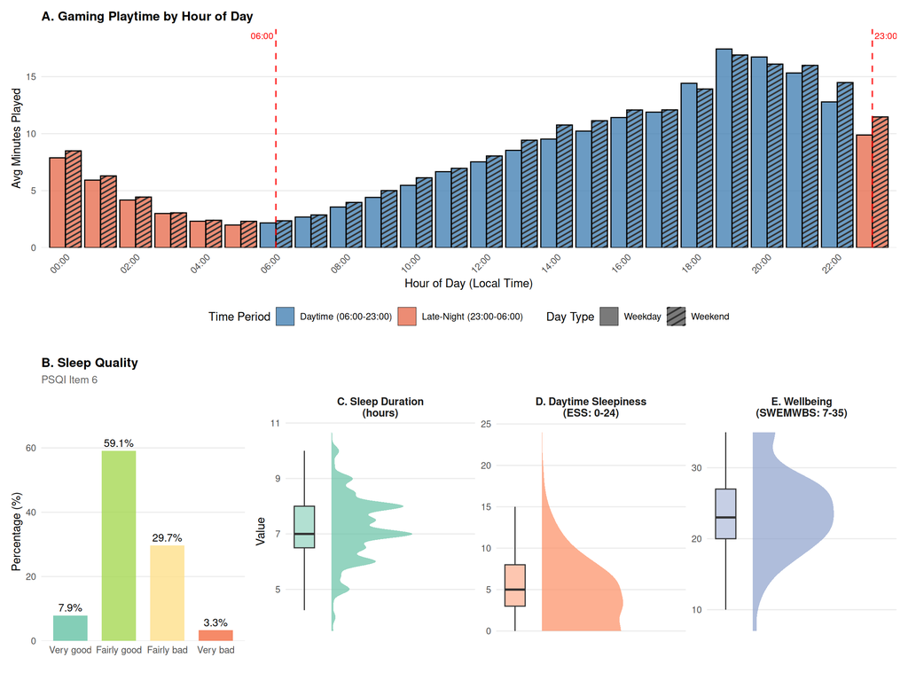

Figure 1: Gaming patterns and outcome distributions. (A) Hourly playtime distribution shows average daily minutes played by hour of day, with grouped bars for weekday (solid) vs weekend (striped) and late-night hours (23:00-06:00) highlighted in red. (B) Sleep Quality shows percentage of responses across ordinal categories. (C-E) Continuous variables displayed as raincloud plots with boxplots (median and IQR) and density distributions.

## H1

The preregistered analyses in the Stage 1 protocol (Ballou et al. 2024) specified four multilevel models in which late-night gaming minutes, averaged over 28 days (monthly) or 14 days (biweekly), predicted sleep quality (H1a), sleep duration (H1b), wellbeing (H1c), and daytime sleepiness (H1d), with random intercepts and random slopes for the late-night gaming exposure by participant and an additional random intercept for gender in the linear models. When applying this specification to the Open Play data, the preregistered random-slope structures led to convergence problems and boundary estimates (near-zero variance components), particularly for the cumulative link mixed model. To obtain stable and interpretable estimates we simplified the random-effects structure to random intercepts for participants (and for gender where supported), and used the multiply imputed outcomes as our primary analytic dataset rather than the incomplete original outcomes.

More concretely, H1a replaces the preregistered random intercept–slope structure `(1 + monthly_avg_minutes_played | pid)` with a random intercept for participants `(1 | pid)`. For H1b, attempts to retain the preregistered random intercept for gender led to non-convergence and boundary estimates, so we instead included gender as a fixed effect and used a single random intercept for participants `(1 | pid)` while keeping the same 28-day late-night average exposure. H1c and H1d follow the same logic of dropping the preregistered random slopes for participants while preserving a random intercept for gender and the same fixed-effect adjustment set.

Under these implemented models, the late-night gaming term in the sleep-quality model (H1a) is estimated as OR = 1.02, 95% CI [1.01, 1.02], p < .001, indicating that each additional minute of average late-night play is associated with a small change in the odds of reporting poorer sleep quality. The corresponding effects are b = -0.00, 95% CI [-0.00, 0.00], p = 0.600 for sleep duration (H1b), suggesting little systematic association between late-night gaming and self-reported sleep hours, b = -0.00, 95% CI [-0.00, 0.00], p = 0.688 for wellbeing (H1c), indicating minimal change in SWEMWBS scores with greater late-night play, and b = 0.00, 95% CI [-0.00, 0.00], p = 0.388 for daytime sleepiness (H1d), again suggesting negligible variation in Epworth scores as a function of late-night gaming. All estimates are computed using the `parameters` package from the easystats ecosystem (Lüdecke et al. 2022). These models additionally adjust for age, BMI, SES index, region, gender, and weekend versus weekday timing, and they use rolling 14- and 28-day windows of late-night play anchored to each survey date. Full coefficient estimates, confidence intervals, and variance components are reported in the H1 regression summary table, to which we refer for all remaining parameters.

Table 2: Summary of H1 Hypotheses: Effects of Late-Night Gaming on Sleep and Wellbeing

H1: Effects of Late-Night Gaming on Sleep and Wellbeing (Imputed data)

|  | H1a: Sleep Quality | H1b: Sleep Duration | H1c: Wellbeing | H1d: Daytime Sleepiness |
| --- | --- | --- | --- | --- |
| Daily LN gaming (monthly) | 0.02 [0.01, 0.02]*** | -0.00 [-0.00, 0.00] |  | 0.00 [-0.00, 0.00] |
| Daily LN gaming (biweekly) |  |  | -0.00 [-0.00, 0.00] |  |
| Age (scaled) | 0.71 [-0.10, 1.51]+ | -0.45 [-0.60, -0.31]*** | 0.07 [-0.55, 0.69] | -0.64 [-1.11, -0.16]** |
| BMI (scaled) | 0.41 [0.07, 0.75]* | -0.07 [-0.13, -0.01]* | -0.20 [-0.46, 0.06] | 0.17 [-0.03, 0.38]+ |
| SES (scaled) | -0.58 [-0.93, -0.23]** | -0.08 [-0.14, -0.02]** | 0.99 [0.73, 1.24]*** | 0.07 [-0.12, 0.27] |
| Region: US | -0.40 [-0.81, 0.02]+ | 0.04 [-0.07, 0.15] | 0.16 [-0.30, 0.62] | 0.20 [-0.15, 0.55] |
| Day: Weekend | 0.02 [-0.35, 0.39] | -0.01 [-0.08, 0.06] | -0.02 [-0.23, 0.19] | 0.03 [-0.20, 0.27] |
| SD (Intercept \| Participant) | 5.67 | 0.90 | 4.17 | 2.93 |
| SD (Residual) |  | 0.56 | 2.47 | 1.79 |
| SD (Intercept \| Gender) |  |  | 1.14 | 0.67 |
| Num.Obs. | 3561 | 3553 | 7425 | 3551 |
| ICC | 0.91 | 0.72 | 0.75 | 0.74 |

+ p < 0.10, * p < 0.05, ** p < 0.01, *** p < 0.001  
LN = late-night. Confidence intervals shown in brackets.  
ICC = Intraclass Correlation Coefficient (adjusted).

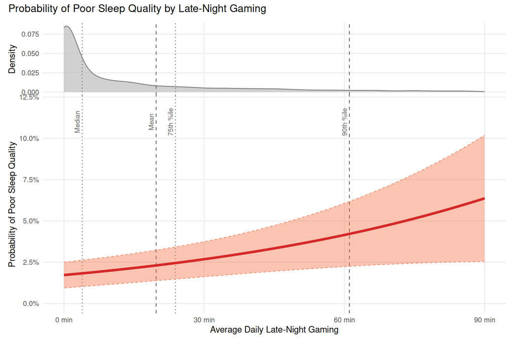

Figure 2: Predicted probability of poor sleep quality as a function of late-night gaming. The line shows the probability of reporting poor sleep quality (Fairly bad or Very bad) at minute-level resolution from 0 to 90 minutes of average daily late-night gaming. The ribbon represents 95% confidence intervals. Vertical reference lines show the median, mean, 75th percentile, and 90th percentile of the sample distribution. The marginal density plot (top panel) shows the distribution of late-night gaming in the sample. Model predictions are derived from the H1a ordinal mixed-effects model adjusting for age, BMI, SES, region, gender, and weekday vs. weekend, with covariates held at their means/reference levels.

## H2

The preregistration in the Stage 1 protocol (Ballou et al. 2024) also specified four moderation models in which raw monthly or biweekly late-night minutes interacted with chronotype (mean sleep-on-free days corrected for sleep debt on weekdays) to predict the same four outcomes (H2a–H2d), again with random intercepts and random slopes for late-night gaming by participant and a random intercept for gender in the linear mixed models. In the analytical sample, median chronotype was 5.9 hours with an interquartile range of 3.1 hours. When transferred to the Open Play data, the preregistered moderation structure proved too demanding: the combination of highly skewed late-night exposure, strong collinearity between chronotype and late-night play, and the cumulative link mixed model for ordinal sleep quality led to non-convergence and nearly singular variance–covariance matrices, particularly for H2a.

In the final models we therefore mean-centred chronotype (`msf_sc_centered`) and simplified the random-effects structures to random intercepts for participants (and for gender where supported), while keeping the interaction terms for all four outcomes. Relative to the preregistration, H2a drops the random slope on late-night minutes for participants and uses the centred chronotype term, H2b simplifies `(1 + monthly_avg_minutes_played | pid)` to `(1 | pid)` while retaining `(1 | gender)`, H2c already specified a random-intercept-only structure for participants and mainly deviates through the use of centred chronotype, and H2d mirrors H2b in simplifying the participant random effects from `(1 + monthly_avg_minutes_played | pid)` to `(1 | pid)` alongside the same chronotype centring. The ordinal H2a model still exhibits known identifiability issues for cumulative link mixed models with interactions, so its interaction term is interpreted cautiously and our substantive conclusions about moderation rely primarily on the linear mixed-effects models (H2b–H2d). As with H1, the full pattern of main and interaction effects, along with random-effect estimates, is presented in the H2 regression summary table.

Although not part of our preregistered hypotheses, the main effect of late-night gaming in the sleep-quality model (H2a) was OR = 1.02, 95% CI [NaN, NaN] and the main effect of chronotype was b = 0.07, 95% CI [NaN, NaN], indicating only modest associations between each predictor and subjective sleep quality when considered marginally. Analogous main effects were b = -0.00, 95% CI [-0.00, 0.00], p = 0.265 and b = -0.02, 95% CI [-0.04, 0.00], p = 0.092 for sleep duration (H2b), b = 0.00, 95% CI [0.00, 0.01], p = 0.043 and b = -0.07, 95% CI [-0.16, 0.01], p = 0.092 for wellbeing (H2c), and b = 0.00, 95% CI [-0.00, 0.01], p = 0.355 and b = 0.03, 95% CI [-0.03, 0.09], p = 0.388 for daytime sleepiness (H2d), which likewise suggest that, in this sample, both chronotype and late-night gaming showed at most small marginal associations with the outcomes once covariates were controlled. These exploratory estimates are reported for completeness, but should be interpreted cautiously given their non-preregistered status.

Table 3: Summary of H2 Hypotheses: Chronotype Moderation of Late-Night Gaming Effects

H2: Chronotype Moderation of Late-Night Gaming Effects (Imputed data)

|  | H2a: Sleep Quality | H2b: Sleep Duration | H2c: Wellbeing | H2d: Daytime Sleepiness |
| --- | --- | --- | --- | --- |
| Daily LN gaming (monthly) | 0.02 | -0.00 [-0.00, 0.00] |  | 0.00 [-0.00, 0.01] |
| Daily LN gaming (biweekly) |  |  | 0.00 [0.00, 0.01]* |  |
| Chronotype (centered) | 0.07 | -0.02 [-0.04, 0.00]+ | -0.07 [-0.16, 0.01]+ | 0.03 [-0.03, 0.09] |
| LN gaming × Chronotype (monthly) | -0.00 | 0.00 [-0.00, 0.00] |  | -0.00 [-0.00, 0.00] |
| LN gaming × Chronotype (biweekly) |  |  | -0.00 [-0.00, -0.00]* |  |
| Age (scaled) | 0.00 | -0.46 [-0.65, -0.28]*** | 0.14 [-0.65, 0.94] | -0.87 [-1.43, -0.32]** |
| BMI (scaled) | 0.02 | -0.04 [-0.11, 0.03] | -0.05 [-0.36, 0.26] | 0.13 [-0.09, 0.34] |
| SES (scaled) | -0.73 | -0.08 [-0.16, -0.01]* | 1.08 [0.76, 1.40]*** | 0.09 [-0.14, 0.31] |
| Region: US | -0.84 | -0.03 [-0.16, 0.11] | 0.24 [-0.33, 0.81] | 0.32 [-0.08, 0.72] |
| Day: Weekend | 0.37 | -0.00 [-0.09, 0.08] | -0.05 [-0.30, 0.19] | 0.03 [-0.22, 0.28] |
| SD (Intercept \| Participant) | 5.32 | 0.91 | 4.01 | 2.73 |
| SD (Intercept \| Gender) |  | 0.03 | 0.79 | 0.35 |
| SD (Residual) |  | 0.54 | 2.30 | 1.56 |
| Num.Obs. | 2580 | 2580 | 5160 | 2580 |
| ICC | 0.90 | 0.74 | 0.76 | 0.76 |

+ p < 0.10, * p < 0.05, ** p < 0.01, *** p < 0.001  
LN = late-night. Confidence intervals shown in brackets.  
ICC = Intraclass Correlation Coefficient (adjusted).

# Discussion

Our findings from a sample of adult gamers revealed patterns consistent with prior research: while sleep duration remained relatively preserved (7.2 hours), sleep quality showed greater impairment, with 64% classified as poor sleepers. These patterns suggest that sleep quality and architecture may be more vulnerable to disruption than sleep duration in the context of regular gaming behavior.

## Limitations

First, our telemetry and survey instruments capture console and PC play but exclude mobile platforms. Gaming on smartphones and tablets forms a substantial share of late-night leisure, particularly in bed where devices are at arm’s reach and can bypass household curfews. Phones also double as tools for emotional regulation, relaxation, and boredom relief before sleep or when people wake up during the night, further increasing the odds that meaningful late-night gaming takes place on devices we do not observe. Any late-night gaming minutes that shifted to mobile therefore go unmeasured, likely biasing exposure downward and attenuating observed associations with sleep. Related activities on the same devices like short-form video viewing, doomscrolling, messaging are also missing, preventing us from disentangling gaming-specific effects from broader nocturnal screen engagement.

Second, the analytic sample consists of early adults. This demographic is commercially important for platform gaming, yet the educational and developmental stakes that motivate policy debates revolve around children and adolescents. Younger players have different sleep physiology, earlier school start times, tighter parental controls, and distinct motivational profiles that could amplify or dampen the impact of late-night play. Our estimates should not be generalized to pediatric populations (or to older adults with different health burdens) without direct evidence.

Third, recruitment relied on UK- and US-based majority Prolific panels, which may diverge markedly from the general gaming population for several reasons. Prolific users are self-selected online workers with reliable broadband, high digital literacy, and the patience for repeated surveys. Platform eligibility emphasizes UK/US residency, English fluency, and adherence to Prolific’s compliance checks, which excludes players in other linguistic, cultural, and regulatory contexts. Incentives attract habitual survey takers with flexible schedules, potentially underrepresenting shift workers, caregivers, or gamers with highly variable sleep routines. Community standards and attention checks may dissuade individuals engaged in more extreme, unregulated, or stigmatized gaming profiles from participating, while payment infrastructures and screening filters can limit participation from lower-income players, people without stable online payment methods, and those who distrust research platforms.

Finally, although logged telemetry is widely recommended for media-effects research—and we did find that it is strongly correlated with self-reported video game play—it is not without limitations. Session-level records cannot distinguish between active engagement and idle time, and this ambiguity is especially pronounced for late-night gaming, where consoles or PCs might stay on while players drift off to sleep or attend to household chores. Such overestimation of exposure could mask true associations or produce spurious late-night “activity” that does not reflect cognitive arousal.

Taken together, the lack of mobile telemetry, the age range of the sample, the geographic/panel constraints, and the inability to rule out idle device time mean that our findings speak most directly to digitally engaged young adults in the UK and US who play on major console and PC ecosystems. Extending the conclusions to other regions, life stages, device ecologies, or logging systems should await complementary data sources.

# References

Altintas, E., Y. Karaca, T. Hullaert, and P. Tassi. 2019. “Sleep Quality and Video Game Playing: Effect of Intensity of Video Game Playing and Mental Health.” *Psychiatry Research* 273: 487–92. https://doi.org/10.1016/j.psychres.2019.01.030.

Ballou, Nick, Tamás A Földes, Matti Vuorre, Thomas Hakman, Kristoffer Magnusson, and Andrew K Przybylski. 2025. “Open Play: A Longitudinal Dataset of Multi-Platform Video Game Digital Trace Data and Psychological Measures.” *PsyArXiv*. https://doi.org/10.31234/osf.io/nz96c_v1.

Ballou, Nick, Thomas Hakman, Tamás A. Földes, Matti Vuorre, Kristoffer Magnusson, and Andrew K. Przybylski. 2024. “Psychological Wellbeing, Sleep, and Video Gaming: Analyses of Comprehensive Digital Traces.” https://osf.io/mvngt.

Bruni, O., S. Sette, L. Fontanesi, R. Baiocco, F. Laghi, and E. Baumgartner. 2015. “Technology Use and Sleep Quality in Preadolescence and Adolescence.” *Journal of Clinical Sleep Medicine* 11 (12): 1433–41. https://doi.org/10.5664/jcsm.5282.

Buysse, D. J., C. F. Reynolds, T. H. Monk, S. R. Berman, and D. J. Kupfer. 1989. “The Pittsburgh Sleep Quality Index: A New Instrument for Psychiatric Practice and Research.” *Psychiatry Research* 28 (2): 193–213. https://doi.org/10.1016/0165-1781(89)90047-4.

Cain, N., and M. Gradisar. 2010. “Electronic Media Use and Sleep in School-Aged Children and Adolescents: A Review.” *Sleep Medicine* 11 (8): 735–42. https://doi.org/10.1016/j.sleep.2010.02.006.

Exelmans, L., and J. Van Den Bulck. 2015. “Sleep Quality Is Negatively Related to Video Gaming Volume in Adults.” *Journal of Sleep Research* 24 (2): 189–96. https://doi.org/10.1111/jsr.12255.

Fernandes, G., J. Vallim, V. D’Almeida, S. Tufik, and M. Andersen. 2023. “The Effects of Social Jetlag and Sleep Variability on Sleepiness in a Population-Based Study: The Mediating Role of Sleep Debt.” *Journal of Sleep Research* 33. https://doi.org/10.1111/jsr.14043.

Gadie, Andrew, Meredith A. Shafto, Y. Leng, and R. Kievit. 2016. “How Are Age-Related Differences in Sleep Quality Associated with Health Outcomes? An Epidemiological Investigation in a UK Cohort of 2406 Adults.” *BMJ Open* 7. https://doi.org/10.1136/bmjopen-2016-014920.

Gumport, N. B., C. E. Gasperetti, J. S. Silk, and A. G. Harvey. 2021. “The Impact of Television, Electronic Games, and Social Technology Use on Sleep and Health in Adolescents with an Evening Circadian Preference.” *Journal of Youth and Adolescence* 50 (12): 2351–62. https://doi.org/10.1007/s10964-021-01429-9.

Han, X., E. Zhou, and D. Liu. 2024. “Electronic Media Use and Sleep Quality: Updated Systematic Review and Meta-Analysis.” *Journal of Medical Internet Research* 26 (1): e48356. https://doi.org/10.2196/48356.

Hartmann, M., M. A. Pelzl, P. H. Kann, U. Koehler, M. Betz, O. Hildebrandt, and W. Cassel. 2019. “The Effects of Prolonged Single Night Session of Videogaming on Sleep and Declarative Memory.” *PLoS ONE* 14 (11): e0224893. https://doi.org/10.1371/journal.pone.0224893.

Higuchi, S., Y. Motohashi, Y. Liu, and A. Maeda. 2005. “Effects of Playing a Computer Game Using a Bright Display on Presleep Physiological Variables, Sleep Latency, Slow Wave Sleep and REM Sleep.” *Journal of Sleep Research* 14 (3): 267–73. https://doi.org/10.1111/j.1365-2869.2005.00463.x.

Johns, M. W. 1991. “A New Method for Measuring Daytime Sleepiness: The Epworth Sleepiness Scale.” *Sleep* 14 (6): 540–45. https://doi.org/10.1093/sleep/14.6.540.

King, D. L., and P. Delfabbro. 2009. “Understanding and Assisting Excessive Players of Video Games: A Community Psychology Perspective.” *Australian Community Psychologist* 21 (1): 62–74.

King, D. L., M. Gradisar, A. Drummond, N. Lovato, J. Wessel, G. Micic, P. Douglas, and P. Delfabbro. 2013. “The Impact of Prolonged Violent Video-Gaming on Adolescent Sleep: An Experimental Study.” *Journal of Sleep Research* 22 (2): 137–43. https://doi.org/10.1111/j.1365-2869.2012.01060.x.

Kortesoja, L., M.-P. Vainikainen, R. Hotulainen, and I. Merikanto. 2023. “Late-Night Digital Media Use in Relation to Chronotype, Sleep and Tiredness on School Days in Adolescence.” *Journal of Youth and Adolescence* 52 (2): 419–33. https://doi.org/10.1007/s10964-022-01703-4.

Kristensen, J. H., S. Pallesen, D. L. King, M. Hysing, and E. K. Erevik. 2021. “Problematic Gaming and Sleep: A Systematic Review and Meta-Analysis.” *Frontiers in Psychiatry* 12. https://doi.org/10.3389/fpsyt.2021.675237.

LeBourgeois, M. K., L. Hale, A.-M. Chang, L. D. Akacem, H. E. Montgomery-Downs, and O. M. Buxton. 2017. “Digital Media and Sleep in Childhood and Adolescence.” *Pediatrics* 140 (Supplement_2): S92–96. https://doi.org/10.1542/peds.2016-1758J.

Lemola, S., S. Brand, N. Vogler, N. Perkinson-Gloor, M. Allemand, and A. Grob. 2011. “Habitual Computer Game Playing at Night Is Related to Depressive Symptoms.” *Personality and Individual Differences* 51 (2): 117–22. https://doi.org/10.1016/j.paid.2011.03.024.

Lüdecke, Daniel, Mattan S. Ben-Shachar, Indrajeet Patil, Brenton M. Wiernik, Etienne Bacher, Rémi Thériault, and Dominique Makowski. 2022. “Easystats: Framework for Easy Statistical Modeling, Visualization, and Reporting.” *CRAN*. https://doi.org/10.32614/CRAN.package.easystats.

McCoy, J. G., and R. E. Strecker. 2011. “The Cognitive Cost of Sleep Lost.” *Neurobiology of Learning and Memory* 96 (4): 564–82. https://doi.org/10.1016/j.nlm.2011.07.004.

Peracchia, S., and G. Curcio. 2018. “Exposure to Video Games: Effects on Sleep and on Post-Sleep Cognitive Abilities. A Sistematic Review of Experimental Evidences.” *Sleep Science* 11 (04): 302–14. https://doi.org/10.5935/1984-0063.20180046.

Pirrone, D., R. J. J. M. van den Eijnden, and M. Peeters. 2024. “Why We Can’t Stop: The Impact of Rewarding Elements in Videogames on Adolescents’ Problematic Gaming Behavior.” *Media Psychology* 27 (3): 379–400. https://doi.org/10.1080/15213269.2023.2242260.

Reardon, A., K. Lushington, and A. Agostini. 2023. “Adolescent Sleep, Distress, and Technology Use: Weekday Versus Weekend.” *Child and Adolescent Mental Health* 28 (1): 108–16. https://doi.org/10.1111/camh.12616.

Roenneberg, T., A. Wirz-Justice, and M. Merrow. 2003. “Life Between Clocks: Daily Temporal Patterns of Human Chronotypes.” *Journal of Biological Rhythms* 18 (1): 80–90. https://doi.org/10.1177/0748730402239679.

Simon, E. B., R. Vallat, C. M. Barnes, and M. P. Walker. 2020. “Sleep Loss and the Socio-Emotional Brain.” *Trends in Cognitive Sciences* 24 (6): 435–50. https://doi.org/10.1016/j.tics.2020.02.003.

Smith, L. J., D. L. King, C. Richardson, B. M. Roane, and M. Gradisar. 2017. “Mechanisms Influencing Older Adolescents’ Bedtimes During Videogaming: The Roles of Game Difficulty and Flow.” *Sleep Medicine* 39: 70–76. https://doi.org/10.1016/j.sleep.2017.09.002.

Spada, M. M., and G. Caselli. 2017. “The Metacognitions about Online Gaming Scale: Development and Psychometric Properties.” *Addictive Behaviors* 64: 281–86. https://doi.org/10.1016/j.addbeh.2015.07.007.

Tennant, R., L. Hiller, R. Fishwick, S. Platt, S. Joseph, S. Weich, J. Parkinson, J. Secker, and S. Stewart-Brown. 2007. “The Warwick-Edinburgh Mental Well-Being Scale (WEMWBS): Development and UK Validation.” *Health and Quality of Life Outcomes* 5 (1): 63. https://doi.org/10.1186/1477-7525-5-63.

Twenge, J. M. 2019. “More Time on Technology, Less Happiness? Associations Between Digital-Media Use and Psychological Well-Being.” *Current Directions in Psychological Science* 28 (4): 372–79. https://doi.org/10.1177/0963721419838244.

Vriend, J. L., F. D. Davidson, P. V. Corkum, B. Rusak, C. T. Chambers, and E. N. McLaughlin. 2013. “Manipulating Sleep Duration Alters Emotional Functioning and Cognitive Performance in Children.” *Journal of Pediatric Psychology* 38 (10): 1058–69. https://doi.org/10.1093/jpepsy/jst033.

Weaver, E., M. Gradisar, H. Dohnt, N. Lovato, and P. Douglas. 2010. “The Effect of Presleep Video-Game Playing on Adolescent Sleep.” *Journal of Clinical Sleep Medicine* 06 (02): 184–89. https://doi.org/10.5664/jcsm.27769.

Williams, D., N. Yee, and S. E. Caplan. 2008. “Who Plays, How Much, and Why? Debunking the Stereotypical Gamer Profile.” *Journal of Computer-Mediated Communication* 13 (4): 993–1018. https://doi.org/10.1111/j.1083-6101.2008.00428.x.

Wu, Shuai, M. Peng, Yuhua Zuo, Mengmeng Wang, Zhaoyan Feng, Huanhuan Wang, Mingze Sun, et al. 2025. “Social Jetlag and Obstructive Sleep Apnea Severity: A Retrospective Study Based on Polysomnography.” *Sleep Medicine* 134: 106722. https://doi.org/10.1016/j.sleep.2025.106722.

# Appendix: Complete-Case Regression Tables

The tables below reproduce the H1 and H2 regression summaries using complete-case data (excluding observations where the outcome was imputed). They correspond to the complete-case analyses referenced in the main text and serve as a sensitivity check alongside the imputed results.

### H1 Sensitivity Analysis: Complete-Case (Non-Imputed Data)

These models use only observations where the outcome variable was NOT imputed (complete-case analysis per outcome). Sample sizes are smaller than the main imputed analyses, as rows with imputed outcomes are excluded.

Appendix H1: Effects of Late-Night Gaming (Complete-Case Analysis)

|  | H1a: Sleep Quality | H1b: Sleep Duration | H1c: Wellbeing | H1d: Daytime Sleepiness |
| --- | --- | --- | --- | --- |
| Daily LN gaming (monthly) | 0.01 [0.01, 0.02]*** | -0.00 [-0.00, 0.00] |  | 0.00 [-0.00, 0.01] |
| Daily LN gaming (biweekly) |  |  | -0.00 [-0.01, 0.00] |  |
| Age (scaled) | 0.46 [-0.23, 1.14] | -0.44 [-0.61, -0.27]*** | 0.08 [-0.57, 0.72] | -0.80 [-1.36, -0.24]** |
| BMI (scaled) | 0.42 [0.13, 0.72]** | -0.09 [-0.16, -0.02]* | -0.19 [-0.47, 0.08] | 0.23 [-0.01, 0.47]+ |
| SES (scaled) | -0.47 [-0.77, -0.18]** | -0.10 [-0.18, -0.03]** | 0.95 [0.68, 1.22]*** | 0.15 [-0.09, 0.39] |
| Region: US | -0.42 [-0.94, 0.10] | 0.06 [-0.07, 0.19] | 0.18 [-0.31, 0.66] | 0.28 [-0.15, 0.70] |
| Day: Weekend | 0.02 [-0.35, 0.39] | 0.02 [-0.07, 0.11] | -0.01 [-0.27, 0.24] | -0.00 [-0.31, 0.31] |
| SD (Intercept \| Participant) | 4.00 | 0.96 | 4.22 | 3.12 |
| SD (Residual) |  | 0.66 | 2.82 | 2.17 |
| SD (Intercept \| Gender) |  |  | 1.20 | 0.11 |
| Num.Obs. | 2501 | 2493 | 5727 | 2491 |
| ICC | 0.83 | 0.68 | 0.71 | 0.67 |

+ p < 0.10, * p < 0.05, ** p < 0.01, *** p < 0.001  
LN = late-night. Confidence intervals shown in brackets.  
ICC = Intraclass Correlation Coefficient (adjusted).

### H2 Sensitivity Analysis: Complete-Case (Non-Imputed Data)

These models use only observations where the outcome variable was NOT imputed (complete-case analysis per outcome). Sample sizes are smaller than the main imputed analyses, as rows with imputed outcomes are excluded.

Appendix H2: Chronotype Moderation (Complete-Case Analysis)

|  | H2a: Sleep Quality | H2b: Sleep Duration | H2c: Wellbeing | H2d: Daytime Sleepiness |
| --- | --- | --- | --- | --- |
| Daily LN gaming (monthly) | 0.02 | -0.00 [-0.00, 0.00] |  | 0.00 [-0.00, 0.01] |
| Daily LN gaming (biweekly) |  |  | 0.00 [-0.00, 0.01] |  |
| Chronotype (centered) | 0.04 | -0.02 [-0.05, 0.01] | -0.05 [-0.15, 0.04] | 0.02 [-0.07, 0.11] |
| LN gaming × Chronotype (monthly) | -0.00 | 0.00 [-0.00, 0.00]+ |  | -0.00 [-0.00, 0.00] |
| LN gaming × Chronotype (biweekly) |  |  | -0.00 [-0.00, -0.00]* |  |
| Age (scaled) | 0.04 | -0.43 [-0.67, -0.19]*** | 0.16 [-0.69, 1.01] | -1.18 [-1.90, -0.46]** |
| BMI (scaled) | 0.12 | -0.06 [-0.15, 0.04] | -0.04 [-0.37, 0.30] | 0.19 [-0.09, 0.48] |
| SES (scaled) | -0.67 | -0.11 [-0.21, -0.01]* | 1.05 [0.71, 1.40]*** | 0.22 [-0.08, 0.52] |
| Region: US | -0.59 | -0.02 [-0.20, 0.16] | 0.26 [-0.36, 0.88] | 0.51 [-0.02, 1.05]+ |
| Day: Weekend | 0.06 | 0.05 [-0.08, 0.17] | -0.08 [-0.40, 0.24] | -0.02 [-0.39, 0.35] |
| SD (Intercept \| Participant) | 4.96 | 1.02 | 4.12 | 3.03 |
| SD (Intercept \| Gender) |  | 0.04 | 0.85 | 0.33 |
| SD (Residual) |  | 0.68 | 2.79 | 2.03 |
| Num.Obs. | 1520 | 1520 | 3462 | 1520 |
| ICC | 0.88 | 0.69 | 0.69 | 0.69 |

+ p < 0.10, * p < 0.05, ** p < 0.01, *** p < 0.001  
LN = late-night. Confidence intervals shown in brackets.  
ICC = Intraclass Correlation Coefficient (adjusted).

### Wave-Level Missingness (Pre-Imputation Data)

We summarised the extent of missingness for the key self-report outcomes across each survey wave in the raw data before imputation. The `Observations` column reports the number of participants in a wave who completed at least one of the listed measures; the percentages in each row are calculated relative to that wave-specific participant count.

Wave-level missingness for key self-report measures (pre-imputation data)

| Wave | Observations | Sleep quality (PSQI item 6) | Sleep duration (hours) | Daytime sleepiness (ESS) | Wellbeing (SWEMWBS) |
| --- | --- | --- | --- | --- | --- |
| 1 | 1577 |  |  |  | 0 (0.0%) |
| 2 | 1355 | 233 (17.2%) | 243 (17.9%) | 241 (17.8%) | 232 (17.1%) |
| 3 | 1307 |  |  |  | 259 (19.8%) |
| 4 | 1246 | 331 (26.6%) | 337 (27.0%) | 335 (26.9%) | 329 (26.4%) |
| 5 | 1217 |  |  |  | 379 (31.1%) |
| 6 | 1160 | 455 (39.2%) | 459 (39.6%) | 463 (39.9%) | 454 (39.1%) |

# Appendix: PSQI Global Score Sensitivity Analysis

This section presents a sensitivity analysis using the PSQI global score (psqi_global) as an alternative sleep quality outcome. The PSQI global score is the sum of all 7 PSQI component scores (range 0-21, higher = worse sleep quality), providing a continuous measure compared to the ordinal item 6 (psqi_comp1_quality) used in the pre-registered H1a hypothesis.

We fit linear mixed-effects models with the same predictor structure as H1d (daytime sleepiness), comparing results for imputed data vs. complete-case data (excluding observations where PSQI global was imputed).

Table 4: Sensitivity Analysis: PSQI Global Score Models (Imputed vs. Original)

|  | PSQI Global Playtime (Imputed) | PSQI Global Chronotype × Playtime (Imputed) | PSQI Global Playtime (Complete-Case) | PSQI Global Chronotype × Playtime (Complete-Case) |
| --- | --- | --- | --- | --- |
| Daily LN gaming (monthly) | 0.00 [0.00, 0.01]** | 0.00 [0.00, 0.01]** | 0.00 [0.00, 0.01]* | 0.00 [-0.00, 0.01]+ |
| Age (scaled) | 0.51 [0.13, 0.89]** | 0.19 [-0.28, 0.66] | 0.51 [0.07, 0.94]* | 0.15 [-0.44, 0.74] |
| BMI (scaled) | 0.28 [0.12, 0.44]*** | 0.13 [-0.05, 0.31] | 0.31 [0.12, 0.50]** | 0.14 [-0.09, 0.37] |
| SES (scaled) | -0.45 [-0.61, -0.29]*** | -0.42 [-0.61, -0.23]*** | -0.41 [-0.60, -0.22]*** | -0.39 [-0.64, -0.15]** |
| Chronotype (centered) |  | 0.10 [0.04, 0.15]*** |  | 0.10 [0.03, 0.18]** |
| LN gaming × Chronotype (monthly) |  | -0.00 [-0.00, -0.00]* |  | -0.00 [-0.00, 0.00] |
| Region: US | -0.25 [-0.53, 0.04]+ | -0.26 [-0.60, 0.08] | -0.36 [-0.69, -0.03]* | -0.42 [-0.86, 0.02]+ |
| Day: Weekend | -0.16 [-0.34, 0.02]+ | -0.11 [-0.31, 0.09] | -0.24 [-0.47, -0.01]* | -0.19 [-0.48, 0.10] |
| SD (Intercept \| Participant) | 2.37 | 2.32 | 2.48 | 2.52 |
| SD (Intercept \| Gender) | 0.62 | 0.51 | 0.71 | 0.55 |
| SD (Residual) | 1.34 | 1.22 | 1.60 | 1.55 |
| Num.Obs. | 3560 | 2580 | 2500 | 1520 |
| ICC | 0.77 | 0.79 | 0.72 | 0.73 |

+ p < 0.10, * p < 0.05, ** p < 0.01, *** p < 0.001  
PSQI global score range: 0-21 (higher = worse sleep quality)  
Confidence intervals shown in brackets.  
ICC = Intraclass Correlation Coefficient (adjusted).